# 1-Solutions-GenDistance

2026-08-31

# Part I: Read in and Align the Sequences with Clustal-Omega

```r
#Align sequences
dnaSeqs = readDNAStringSet("flu_seqs.fasta")
aligns = msa(dnaSeqs, method="ClustalOmega", order="input")
```

```
## using Gonnet
```

# Part II: Use the Phangorn package to compare substitution models

```r
forPhang = msaConvert(aligns, type="phangorn::phyDat")

mt = modelTest(forPhang, model=c("JC","F81","K80","HKY","TrN"))
```

```
## Model        df  logLik   AIC      BIC
##           JC 93 -4904.812 9995.624 10501.45
##         JC+I 94 -4874.411 9936.822 10448.09
##      JC+G(4) 94 -4873.638 9935.276 10446.54
##    JC+G(4)+I 95 -4873.521 9937.043 10453.75
##          F81 96 -4865.779 9923.559 10445.7
##        F81+I 97 -4835.407 9864.814 10392.39
##     F81+G(4) 97 -4834.678 9863.356 10390.94
##   F81+G(4)+I 98 -4834.576 9865.152 10398.17
##          K80 94 -4760.739 9709.478 10220.74
##        K80+I 95 -4729.585 9649.17 10165.87
##     K80+G(4) 95 -4728.715 9647.429 10164.13
##   K80+G(4)+I 96 -4728.557 9649.113 10171.25
##          HKY 97 -4722.025 9638.05 10165.63
##        HKY+I 98 -4691.185 9578.369 10111.39
##     HKY+G(4) 98 -4690.171 9576.343 10109.36
##   HKY+G(4)+I 99 -4689.992 9577.983 10116.44
##          TrN 98 -4720.702 9637.405 10170.42
##        TrN+I 99 -4689.757 9577.514 10115.97
##     TrN+G(4) 99 -4688.893 9575.785 10114.24
##   TrN+G(4)+I 100 -4688.747 9577.493 10121.39
```

```r
write.table(mt, "modelTest_results.txt", quote=FALSE, sep="\t",row.names=FALSE, col.names=TRUE)
```

## Question 1: The Bayesian Information Criterion (BIC) is a method for comparing models that includes penalties for more complex models. With this method, the best one is the model with the LOWEST BIC score. In your test, which model is this? Describe this model in terms of its assumptions. (5 pts)

The lowest BIC is HKY + G

# Part III: Calculate Genetic Distance Under the Best Model

## Question 2: Show your command for calculating distance, including which model you used in your command, and which option you used for gamma. (1 pt)

```r
dna = as.DNAbin(forPhang)
?dist.dna()
D = dist.dna(dna, model="F84", gamma=FALSE)
```

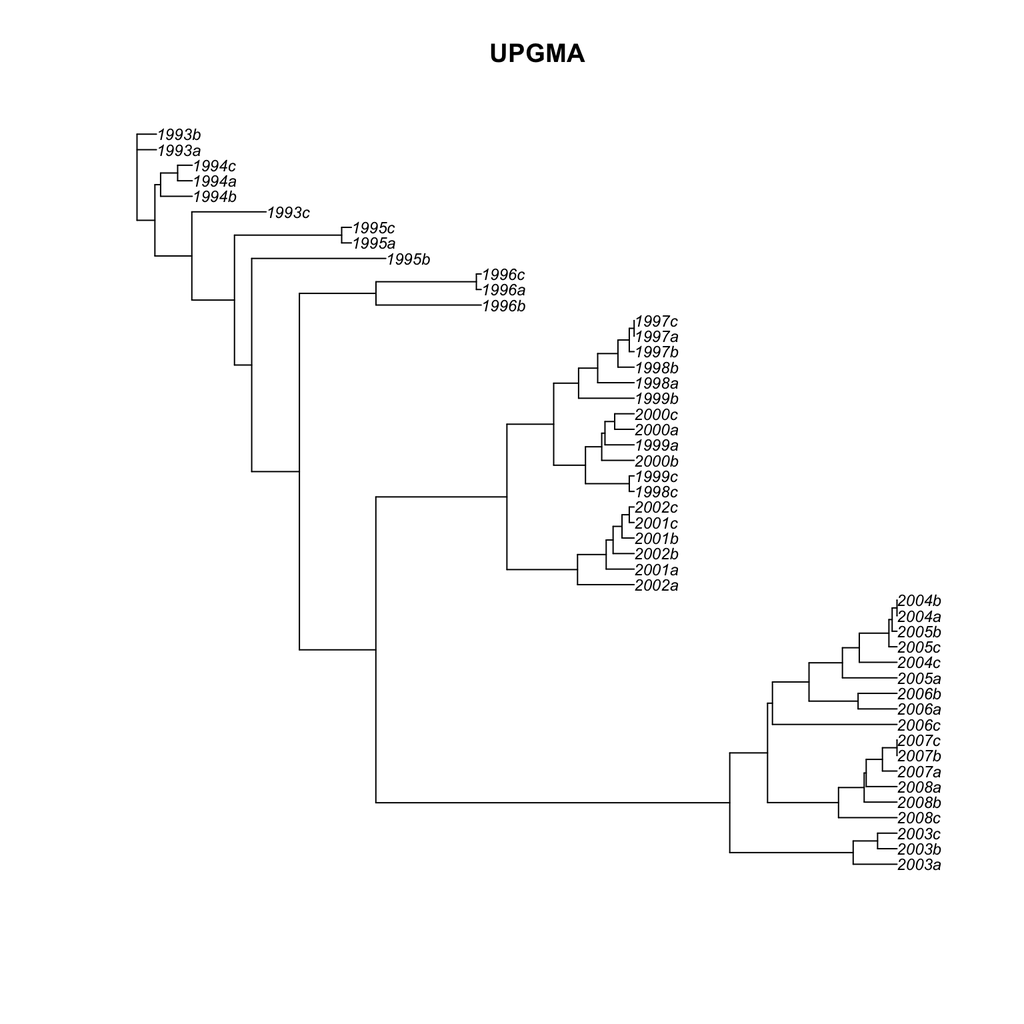

```r
t.upgma = upgma(D)
t.nj = nj(D)
t.upgma.root = root(phy=t.upgma, outgroup='1993a')
t.nj.root = root(phy=t.nj, outgroup='1993a')
plot(t.upgma.root, main="UPGMA", cex=0.75)
```

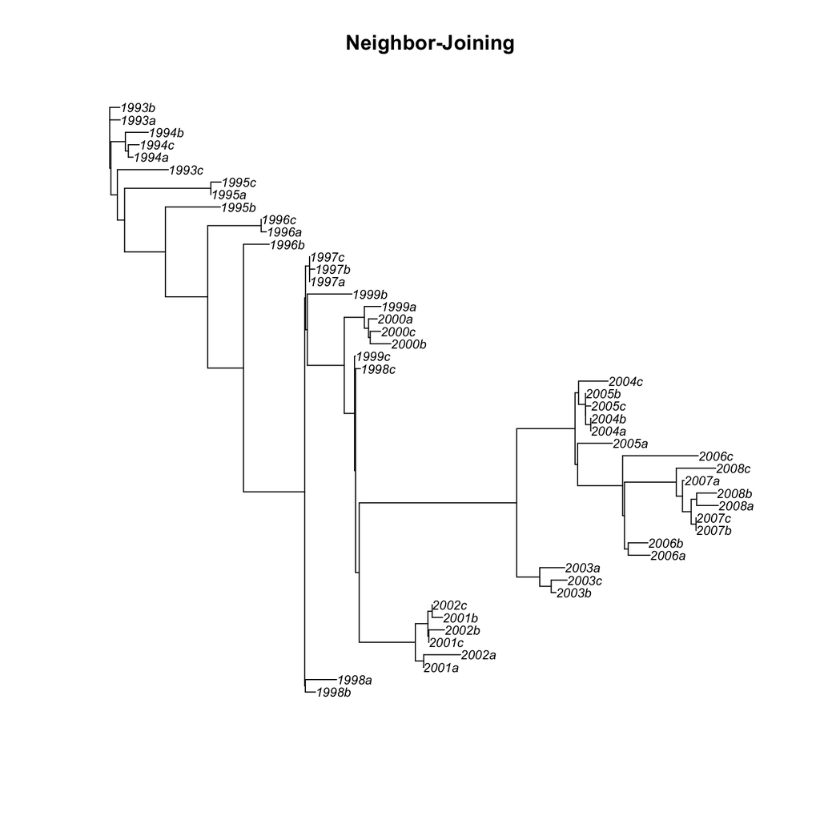

```r
plot(t.nj.root, main="Neighbor-Joining", cex=0.75)
```

```r
treedist(t.upgma.root, t.nj.root)
```

```
##      symmetric.difference   branch.score.difference           path.difference
##               40.00000000                0.01950911              135.70556363
## quadratic.path.difference
##                0.35911714
```

## Question 3: Provide your plots for the rooted UPGMA and rooted Neighbor-Joining trees (be sure they are labeled so I can tell which is which!). Describe any differences you see in the overall appearance of the two trees. Do the same clades appear in each tree? Do viruses collected in later years branch off from the viruses of previous years (like we would expect)? (5 pts)

# Part V: Calculate Distance Metrics Between the 2 Trees

## Question 4: What is the symmetric difference, branch score difference, and path difference between your two trees? Which number implies the biggest difference in the trees? Based on what you know about the definition of these metrics, why would one score be much higher than the others? Does your highest score make sense given what you see when you plot the two trees? (3 pts)

# Part VI: Perform Bootstrapping on the Neighbor-Joining Tree

## Question 5: Provide a plot of your bootstrapped tree. Are there any nodes in your tree that seem to have very weak bootstrap support (i.e. less than 50%)? How many of these weakly supported nodes do you see? Which node has the weakest support, and what clade is this node at the base of? If it is hard to see exactly where the nodes are with the bootstrap labels on them, you might also want to refer back to your original plot without the labels to help you. (3 pts)

```r
myBoots = boot.phylo(t.nj.root, dna, function(x) root(nj(dist.dna(x, model="F84", gamma=TRUE)),1), trees=TRUE)
```

[output not shown]

[output cut: 145 more lines]

[output not shown]

```
## Running bootstraps:       100 / 100
## Calculating bootstrap values... done.
```

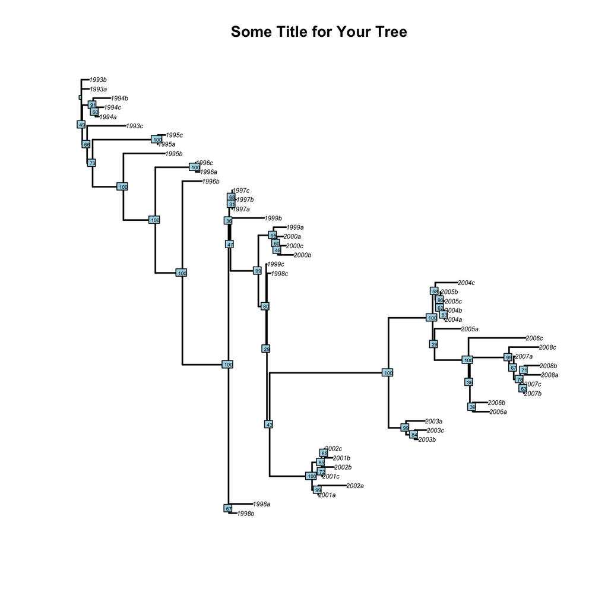

```r
plot(t.nj.root, cex=0.5, edge.width=2, main="Some Title for Your Tree")
nodelabels(myBoots$BP, cex=0.4)
```

## Question 6: Provide a plot of your majority rule consensus tree. (1 pt)

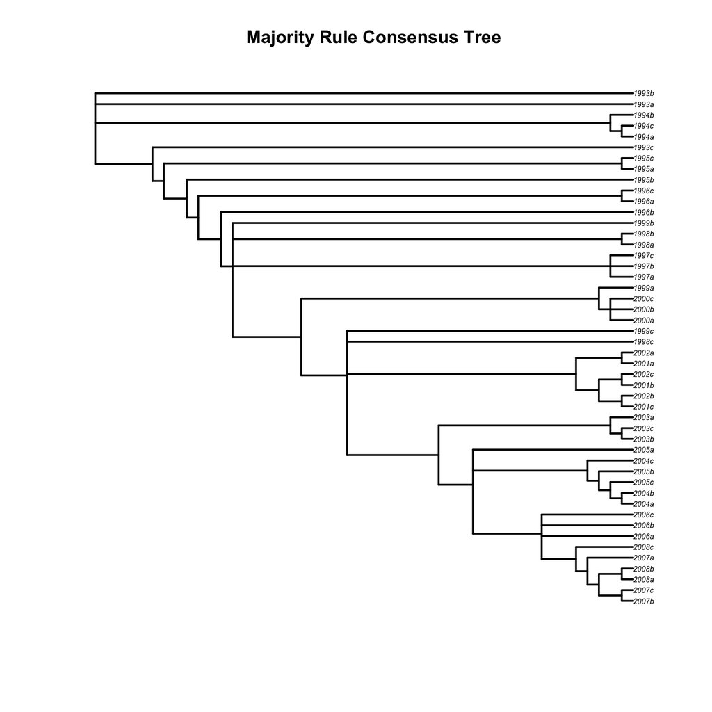

```r
mjtree = consensus(myBoots$trees, p=0.5)
mjtree.root = root(mjtree, outgroup='1993a')
plot(mjtree.root, cex=0.5, edge.width=2, main="Majority Rule Consensus Tree")
```

# Part VII: Find the Most Parsimonious Tree

## Question 7: What are your parsimony scores for your UPGMA and Neighbor-Joining trees? Given that a lower score is better, which of your trees is the most parsimonious? Based on what you know about the definition of parsimony, what does it mean when we say that one tree is more parsimonious than another? i.e. How should we interpret this result? (3 pts)

```r
parsimony(t.upgma.root, forPhang)
```

```
## [1] 377
```

```r
parsimony(t.nj.root, forPhang)
```

```
## [1] 340
```

```r
tre.pars = pratchet(forPhang, start=t.nj)
```

[output not shown]

## Question 9: Provide the plot for your final tree. Even though there are still some uncertain relationships, can you now see any kind of trend with respect to the years the viruses were sampled and where they appear on the tree? Describe your new tree and the trends that you see. (3 pts)

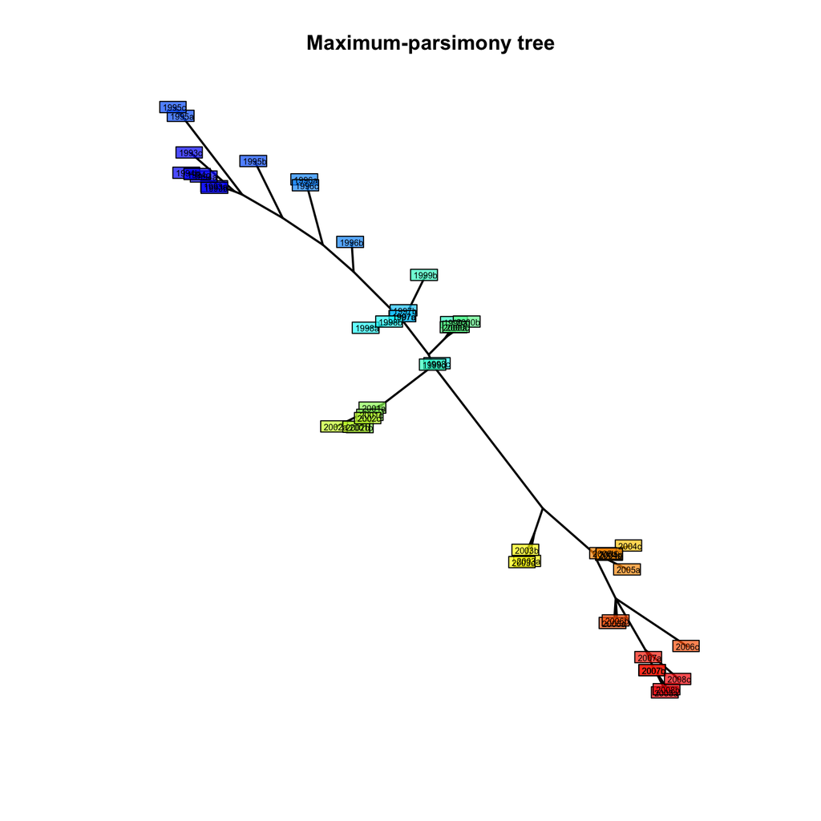

```r
N <- length(t.nj.root$tip.label)
toCollapse <- match(which(myBoots$BP<50)+N, t.nj.root$edge[,2])
t.nj.root$edge.length[toCollapse] = 0
new.tree = di2multi(t.nj.root, tol=0.00001)
plot(new.tree, type="unr", show.tip=FALSE, edge.width=2)
title("Maximum-parsimony tree")


library(basetheme)
library(epicontacts)
year = as.numeric(gsub("[a-c]", "", names(forPhang)))
tiplabels(t.nj.root$tip.label, bg=transp(num2col(year),.7), cex=.5, fg="transparent")
```